# COMPSCIX 415.2 Homework 5/Midterm

Jared Lee

7/3/2018

[Link to my GitHub](https://github.com/jar1818/compscix-415-2-assignments)

```r
library(tidyverse)
library(dplyr)
library(tidyr)
```

## RStudio and R Markdown (3 points)

### 1) Use markdown headers in your document to clearly separate each midterm question and add a table of contents to your document.

Done - TOC at the top of the page.

## The tidyverse packages (3 points)

### 1) Can you name which package is associated with each task below?

1a) Plotting - ggplot2

1b) Data munging/wrangling - dplyr

1c) Reshaping (speading and gathering) data - tidyr

1d) Importing/exporting data - readr

### 2) Now can you name two functions that you’ve used from each package that you listed above for these tasks?

2a) Plotting - geom_point(), geom_boxplot()

2b) Data munging/wrangling - mutate(), filter()

2c) Reshaping data - gather(), spread()

2d) Importing/exporting data - read_csv(), write_csv()

## R Basics (1.5 points)

### 1) Fix this code with the fewest number of changes possible so it works:

```r
#remove exclaimation point
My_data.name___is.too00ooLong <- c( 1 , 2   , 3 )
```

### 2) Fix this code so it works:

```r
#add tick mark at the end of 'it'
my_string <- c('has', 'an', 'error', 'in', 'it')
```

### 3) Look at the code below and comment on what happened to the values in the vector.

```r
# The values in the vector are all converted to Charactors as opposed to being Numeric.
my_vector <- c(1, 2, '3', '4', 5)
glimpse(my_vector)
```

```
##  chr [1:5] "1" "2" "3" "4" "5"
```

## Data import/export (3 points)

### 1) Download the rail_trail.txt file from Canvas (in the Midterm Exam section) and successfully import it into R. Prove that it was imported successfully by including your import code and taking a glimpse of the result.

```r
#Import txt file from desktop
file_path <- '/users/jalee/desktop/rail_trail.txt'
txt_data <- read_csv(file = file_path)
#glimpse data
glimpse(txt_data)
```

```
## Observations: 90
## Variables: 1
## $ `hightemp|lowtemp|avgtemp|spring|summer|fall|cloudcover|precip|volume|weekday` <chr> ...
```

### 2) Export the file into a comma-separated file and name it “rail_trail.csv”. Make sure you define the path correctly so that you know where it gets saved. Then reload the file. Include your export and import code and take another glimpse.

```r
#export to csv
write_csv(txt_data, "/users/jalee/desktop/rail_trail.csv")

#import csv file
file_path_csv <- '/users/jalee/desktop/rail_trail.csv'
csv_data <- read_csv(file = file_path_csv)
#glimpse csv file
glimpse(csv_data)
```

```
## Observations: 90
## Variables: 1
## $ `hightemp|lowtemp|avgtemp|spring|summer|fall|cloudcover|precip|volume|weekday` <chr> ...
```

## Visualization (6 points)

### 1) Critique this graphic: give only three examples of what is wrong with this graphic. Be concise.

1a) Using the areas of circles to compare numbers makes it difficult to visualize the differnce. Bar graphs that have a clear x and y axis for measurements are a better alternative.

1b) The age statistic and the gender statistic are not mutually exclusive metrics, yet they are displayed separately. Instead, the visual should show the proportion of men and women among the different age groups.

1c) Purple and orange colors for men and women are non-sensical as they indicate that a 3rd variable is present. There are two variables: age and gender. However, with 3 colors (black, purple, orange), the graphic implies there are 3 variables.

### 2) Reproduce this graphic using the diamonds data set.

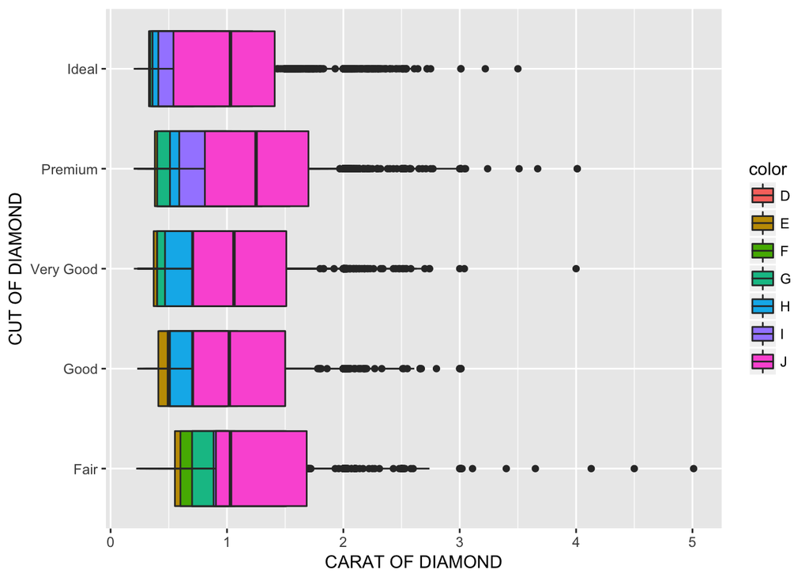

```r
ggplot(diamonds, aes(cut, carat, fill = color)) +
  geom_boxplot(position = "identity") +
  xlab('CUT OF DIAMOND') +
  ylab('CARAT OF DIAMOND') +
  coord_flip()
```

### 3) The previous graphic is not very useful. We can make it much more useful by changing one thing about it. Make the change and plot it again.

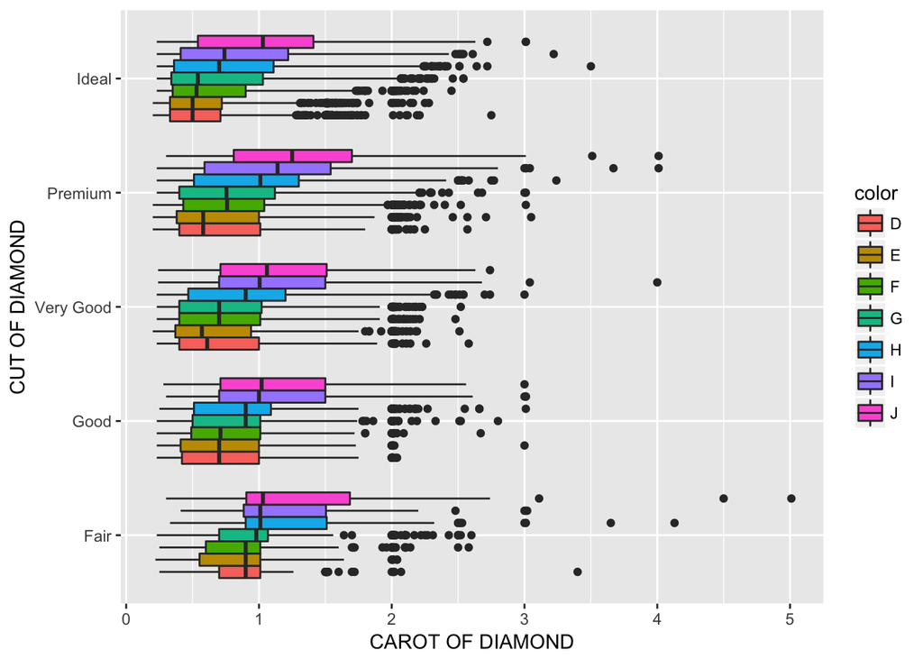

```r
#To prevent overlapping (which hides may of the plots), use position = dodge to separate them.
ggplot(diamonds, aes(cut, carat, fill = color)) +
  geom_boxplot(position = "dodge") +
  xlab('CUT OF DIAMOND') +
  ylab('CAROT OF DIAMOND') +
  coord_flip()
```

## Data munging and wrangling (6 points)

### 1) Is this data “tidy”? If yes, leave it alone and go to the next problem. If no, make it tidy. Note: this data set is called table2 and is available in the tidyverse package. It should be ready for you to use after you’ve loaded the tidyverse package.

```r
#The data is NOT tidy because each variable should have it's own column, thus making each row represent one observation.
table2 %>% spread(key = type, value = count)
```

```
## # A tibble: 6 x 4
##   country      year  cases population
##   <chr>       <int>  <int>      <int>
## 1 Afghanistan  1999    745   19987071
## 2 Afghanistan  2000   2666   20595360
## 3 Brazil       1999  37737  172006362
## 4 Brazil       2000  80488  174504898
## 5 China        1999 212258 1272915272
## 6 China        2000 213766 1280428583
```

### 2) Create a new column in the diamonds data set called price_per_carat that shows the price of each diamond per carat (hint: divide). Only show me the code, not the output.

```r
#Code below
price_per_carat <- diamonds %>% mutate(price_per_carat = price/carat)
```

### 3) For each cut of diamond in the diamonds data set, how many diamonds, and what proportion, have a price > 10000 and a carat < 1.5? There are several ways to get to an answer, but your solution must use the data wrangling verbs from the tidyverse in order to get credit.

```r
#The below code outputs the number of diamonds fitting description (price > 10k, carat < 1.5) and proportion by cut.
diamonds %>%
  mutate(small_10k = (price > 10000 & carat < 1.5)) %>%
  select(cut, price, carat, small_10k) %>%
  dplyr::group_by(cut) %>%
  summarize(total_cnt = n(), fit = sum(small_10k)) %>%
  mutate(proportion = fit/total_cnt)
```

```
## # A tibble: 5 x 4
##   cut       total_cnt   fit proportion
##   <ord>         <int> <int>      <dbl>
## 1 Fair           1610     4    0.00248
## 2 Good           4906    17    0.00347
## 3 Very Good     12082   155    0.0128
## 4 Premium       13791   173    0.0125
## 5 Ideal         21551   485    0.0225
```

#### Do the results make sense? Why?

It makes sense that there are more quality cut diamonds with the higher price point. $10k is quite high for a smaller sized diamond, so it must have an excellent cut (among other qualities) to justify the higher price.

#### Do we need to be wary of any of these numbers? Why?

There are other factors that impact the price of the diamonds including clarity and color. Basing data on only cut and carat may be misleading. Also, there is some missing data where a diamond is missing the x, y, and z values. This could mean there are other errors in the data.

```r
diamonds %>%
  filter(price > 10000 & carat < 1.5) %>%
  filter(x == 0 | y== 0 | z == 0)
```

```
## # A tibble: 1 x 10
##   carat cut     color clarity depth table price     x     y     z
##   <dbl> <ord>   <ord> <ord>   <dbl> <dbl> <int> <dbl> <dbl> <dbl>
## 1   1.2 Premium D     VVS1     62.1    59 15686     0     0     0
```

## EDA (6 points)

### Take a look at the txhousing data set that is included with the ggplot2 package and answer these questions:

#### During what time period is this data from?

Answer: The time period is from January 2000 to July 2015.

```r
#arrange by earliest year
txhousing %>% arrange((date))
```

```
## # A tibble: 8,602 x 9
##    city           year month sales  volume median listings inventory  date
##    <chr>         <int> <int> <dbl>   <dbl>  <dbl>    <dbl>     <dbl> <dbl>
##  1 Abilene        2000     1    72  5.38e6  71400      701       6.3  2000
##  2 Amarillo       2000     1   102  8.86e6  80000      972       5.3  2000
##  3 Arlington      2000     1   241  2.62e7  94000     1417       3.7  2000
##  4 Austin         2000     1  1025  1.73e8 133700     3084       2    2000
##  5 Bay Area       2000     1   244  2.93e7 100700     1766       4.3  2000
##  6 Beaumont       2000     1    97  1.01e7  82100      876       6.1  2000
##  7 Brazoria Cou…  2000     1    55  5.24e6  74400      512       5.9  2000
##  8 Brownsville    2000     1    NA NA          NA      400       9.1  2000
##  9 Bryan-Colleg…  2000     1    61  5.62e6  77900      498       4.2  2000
## 10 Collin County  2000     1   464  9.48e7 158700     2844       4    2000
## # ... with 8,592 more rows
```

```r
#arrange by most recent year
txhousing %>% arrange(desc(date))
```

```
## # A tibble: 8,602 x 9
##    city          year month sales   volume median listings inventory  date
##    <chr>        <int> <int> <dbl>    <dbl>  <dbl>    <dbl>     <dbl> <dbl>
##  1 Abilene       2015     7   268   4.58e7 148700      986       5   2016.
##  2 Amarillo      2015     7   354   6.23e7 149700     1247       4.5 2016.
##  3 Arlington     2015     7   605   1.25e8 178900      752       1.7 2016.
##  4 Austin        2015     7  3466   1.15e9 264600     7913       3   2016.
##  5 Bay Area      2015     7   849   1.97e8 200800     2144       3.2 2016.
##  6 Beaumont      2015     7   318   5.29e7 139300     1561       6.4 2016.
##  7 Brazoria Co…  2015     7    NA  NA          NA       NA      NA   2016.
##  8 Brownsville   2015     7    NA  NA          NA       NA      NA   2016.
##  9 Bryan-Colle…  2015     7   414   9.04e7 190700      894       3.3 2016.
## 10 Collin Coun…  2015     7  1861   6.14e8 292600     2809       2.1 2016.
## # ... with 8,592 more rows
```

#### How many cities are represented?

Answer: 46

```r
#count number of unique cities
txhousing %>%
  distinct(city) %>%
  count()
```

```
## # A tibble: 1 x 1
##       n
##   <int>
## 1    46
```

#### Which city, month and year had the highest number of sales?

Answer: Houston, 2015, July

```r
txhousing %>%
  group_by(city, year, month) %>%
  summarize(sales) %>%
  arrange(desc(sales)) %>%
  head(n=5)
```

```
## # A tibble: 5 x 4
## # Groups:   city, year [3]
##   city     year month sales
##   <chr>   <int> <int> <dbl>
## 1 Houston  2015     7  8945
## 2 Houston  2006     6  8628
## 3 Houston  2013     7  8468
## 4 Houston  2015     6  8449
## 5 Houston  2013     5  8439
```

#### What kind of relationship do you think exists between the number of listings and the number of sales? Check your assumption and show your work.

Answer: I’d expect the number of sales to be fairly linear with the number of listings. From graphing the data, the two are closely related until it reaches an inflection point around 18,000 listings and the number of sales becomes more flat.

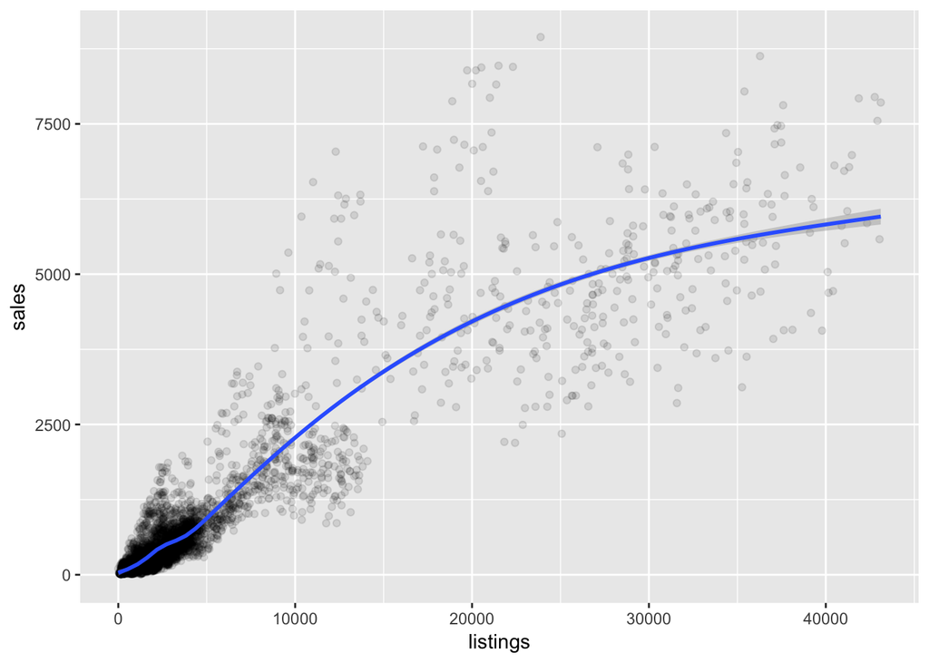

```r
txhousing %>%
  filter(!is.na(sales)) %>%
  filter(!is.na(listings)) %>%
  ggplot(aes(listings, sales)) +
  geom_point(alpha = 1/10) +
  geom_smooth()
```

#### What proportion of sales is missing for each city?

```r
#Calculated the Proportion of missing sales for each city under the "prop_missing" column.
txhousing %>%
  group_by(city) %>%
  summarize(count = n(),
            missing_sales = sum(is.na(sales)),
            prop_missing = missing_sales/count) %>%
  arrange(desc(prop_missing))
```

```
## # A tibble: 46 x 4
##    city               count missing_sales prop_missing
##    <chr>              <int>         <int>        <dbl>
##  1 South Padre Island   187           116       0.620
##  2 Kerrville            187           104       0.556
##  3 Midland              187            75       0.401
##  4 Odessa               187            72       0.385
##  5 San Marcos           187            46       0.246
##  6 Laredo               187            36       0.193
##  7 Harlingen            187            25       0.134
##  8 Waco                 187            19       0.102
##  9 Texarkana            187            17       0.0909
## 10 Brazoria County      187            14       0.0749
## # ... with 36 more rows
```

#### Looking at only the cities and months with greater than 500 sales:

#### Are the distributions of the median sales price (column name median), when grouped by city, different? The same? Show your work.

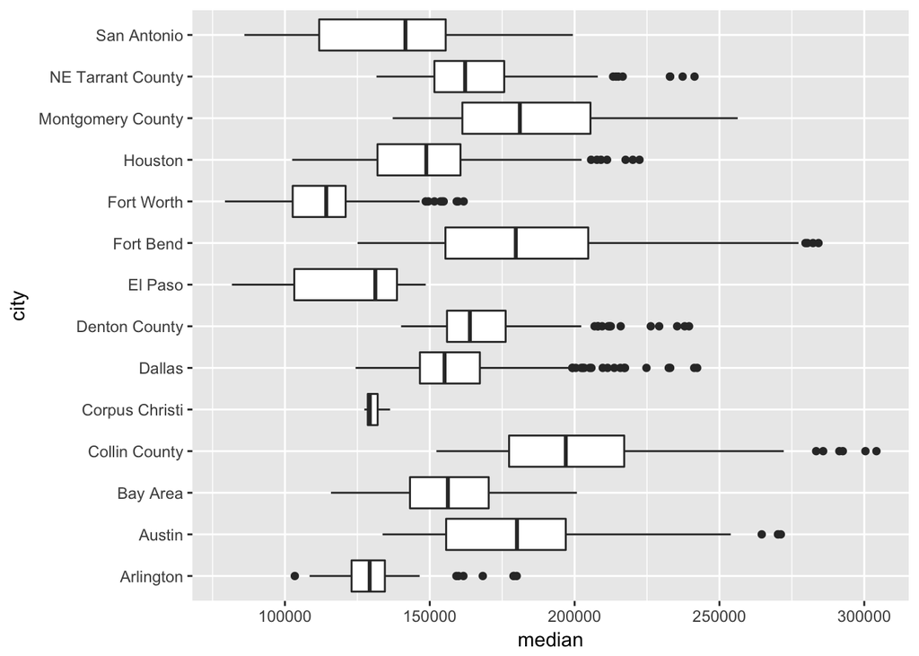

```r
#Distributions of median sales prices are different as the cities have differing interquartile ranges.
txhousing %>%
  filter(sales > 500) %>%
  group_by(city,median) %>%
  summarize() %>%
  ggplot() +
  geom_boxplot(aes(city, median)) +
  coord_flip()
```

#### Any cities that stand out that you’d want to investigate further?

Denton County, Dalles and Colin County appear to have many outliers. It’d be intersting to see the IQR when including the outliers.

#### Why might we want to filter out all cities and months with sales less than 500?

With the high volume of sales less than 500, it’s difficult to reveal any insights. When the data gets more sparce, you can better see what independent variables might drive the prices.

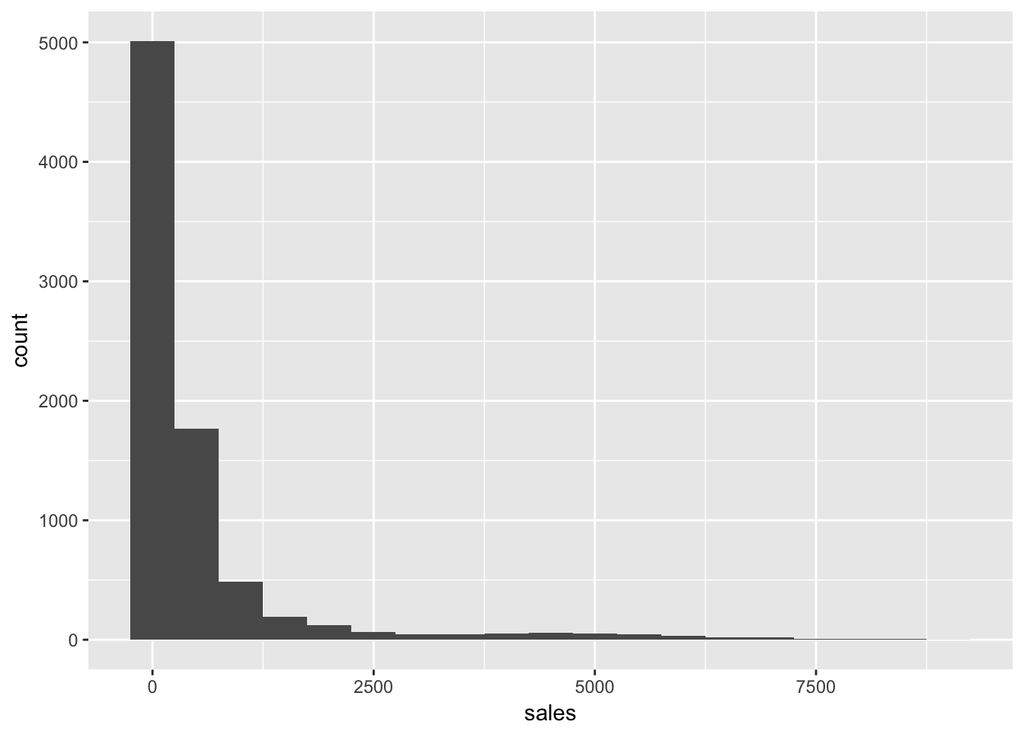

```r
ggplot(txhousing, aes(sales)) +
  geom_bar(binwidth = 500)
```

## Git and Github (1.5 points)

### To demonstrate your use of git and Github, at the top of your document put a hyperlink to your Github repository.

Link at the top of the document.

### Once you are finished with your midterm, commit your final changes with the comment “finished the midterm - woohoo” and push your R Markdown file and your html or pdf file to Github.

Done.